# SC3102 Lab 1

> Gong Zerui 2024.02.14

```python
# import libraries
import matplotlib.pyplot as plt
import numpy as np
from scipy import signal
```

## 1. Basic Representation of signals

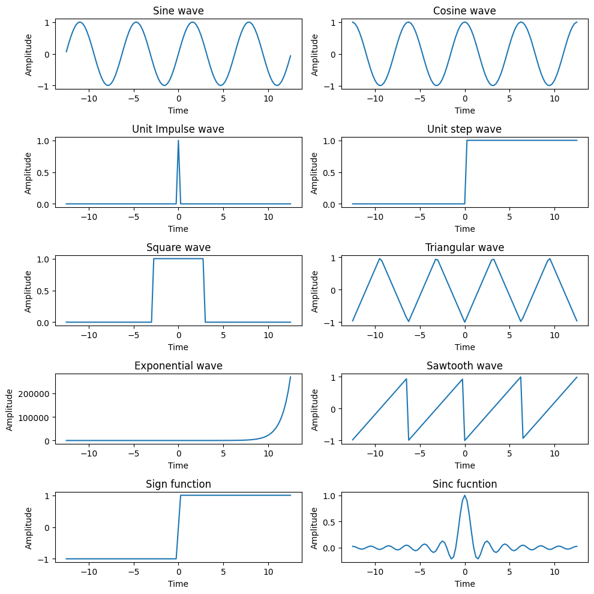

```python
x=np.linspace(-12.5,12.5,101)
plt.figure()
x = np.linspace(-12.5, 12.5, 101)
plt.figure()
#_Fill_in_your_code_here
y1 = np.sin(x)# Sine wave
y2 = np.cos(x)# Cosine wave
y3 = signal.unit_impulse(len(x), 'mid')# Unit impulse wave
y4 = (x>0)# Unit step wave
y5 = (x>-3)*(x<3)# Unit square wave
y6 = signal.sawtooth(x,0.5)# Triangular wave
y7 = np.exp(x)# Exponential wave
y8 =signal.sawtooth(x)# Sawtooth wave
y9 = np.sign(x) # Sign function
y10 = np.sinc(x) # Sinc wave
wave_name = ['Sine wave', 'Cosine wave', 'Unit Impulse wave', 'Unit step wave','Square wave','Triangular wave','Exponential wave','Sawtooth wave','Sign function','Sinc fucntion']
y = [y1,y2,y3,y4,y5,y6,y7,y8,y9,y10]
plt.figure(figsize=(10,10))
for i in range(10):
 plt.subplot(5,2,i+1)
 plt.plot(x, y[i])
 plt.title(wave_name[i])
 plt.ylabel('Amplitude')
 plt.xlabel('Time')
plt.tight_layout()
plt.show()
```

## 2. Time Domain analysis

In this exercise we will work on signals in the time domain. This requires measuring a signal at a constant interval over time. The frequency with which we measure a signal is referred to as the sampling frequency. The units of this are typically described in $Hz$ or the number of cycles per second. It is critical that the sampling frequency is consistent over the entire measurement of the time series.

### 2.1 Sampling theorem

In this subsection we verify the sampling theorem. The definition of proper sampling is quite simple. Suppose we sample a continuous time signal, say a sine wave, in some manner. If we can exactly reconstruct the signal from its samples, then we have done sampling properly.

Generate a sine wave

$$ y(t) = A \sin(2\pi *100t + \pi /6) $$

Shannon sampling theorem states that for actual reconstruction of the signal, an analog signal has to be sampled at least twice the maximum signal frequency. It is also called the Nyquist criteria for sampling. The minimum sampling frequency required for the actual reconstruction of the signal is also called the Nyquist rate. Through this experiment, we are learning the relation of different sampling frequencies for the actual reconstruction of the signal. So, for the above expression, what is the minimum sampling frequency required for the actual reconstruction of the signal? What happens if we sample the signal below the minimum sampling frequency?

Write a python program to demonstrate your reasoning. The program should plot the sine wave y(t) given above sampled at different sampling frequencies. You should test the signal with the following frequency criteria and repeat the exercise with different frequency values

a. Sampling frequency below Nyquist criteria

b. Sampling frequency matching with Nyquist rate

c. Sampling frequency above the Nyquist rate

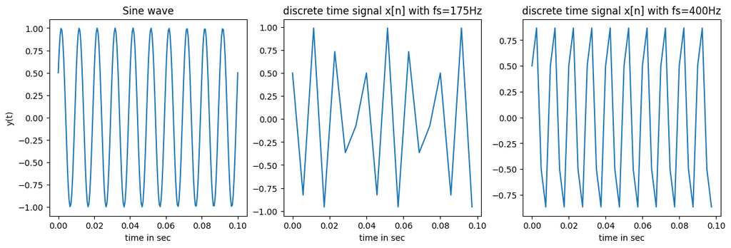

```python
"""
the formula is y(t) = A sin(2πft + φ)
so f is 100Hz and φ is π/6
Nyquist rate is 2*Fm which is 200Hz
"""
Fm=100 #Frequency of sime wave (sampling rate below Nyquist rate)
t1 = np.linspace(0,0.1,200)
y1 = np.sin(2 * np.pi * Fm * t1 + np.pi/6) #Sine wave
fig, axs = plt.subplots(1, 3,figsize=(12, 4),constrained_layout=True)
axs[0].plot(t1,y1,label = 'continuous')
axs[0].set_title("Sine wave")
axs[0].set_xlabel('time in sec')
axs[0].set_ylabel('y(t)')

fs1 = 175 # sampling rate for 175 Hz (sampling rate matching Nyquist rate)
n1 = np.arange(0,0.1*fs1)/fs1
y2 = np.sin(2 * np.pi * Fm * n1 + np.pi/6) #Sine wave
axs[1].plot(n1,y2,label = 'continuous')
axs[1].set_title("discrete time signal x[n] with fs=175Hz")
axs[1].set_xlabel('time in sec')


fs2 = 400 # sampling rate for 400 Hz
n2 = np.arange(0,0.1*fs2)/fs2
y3 = np.sin(2 * np.pi * Fm * n2 + np.pi/6) #Sine wave
axs[2].plot(n2,y3,label = 'continuous')
axs[2].set_title("discrete time signal x[n] with fs=400Hz")
axs[2].set_xlabel('time in sec')
plt.show()
plt.tight_layout()
```

### 2.2. Addition of Two Discrete Time Signals

In this exercise, we will learn to represent signals in their discrete form. Given three signals:

- $y_1(t) = A \cos(2\pi \times 10t)$
- $y_2(t) = B \cos(2\pi \times 15t)$
- $y_3(t) = y_1(t) + y_2(t)$

sampled at $F_s = 60$. Sample code is given below to generate the signals. Complete the code to plot the signals. Using the plots as a reference, answer the following questions. You may change the code as required.

### Questions:

a. Find the discrete time representation of $y_1[n]$, $y_2[n]$, and $y_3[n]$.

b. Find the period of $y_3[n]$.

c. How are the periods of $y_3[n]$ related to $y_1[n]$ and $y_2[n]$?

d. Is $y_3[n]$ an energy or power signal? Find its (energy or power) and compare it against (energy or power) of $y_1[n]$ and $y_2[n]$.

```
Number of samples per cycle N1=6 N2=4 LCM = 12
```

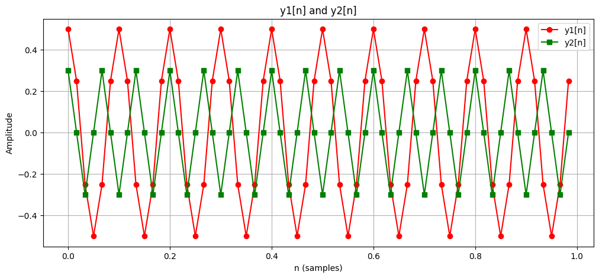

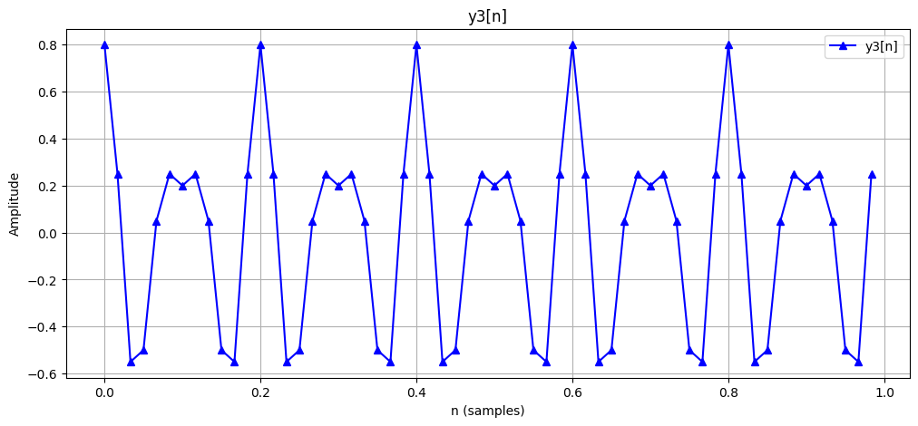

```python
# Define gcd function
def gcd(x, y):
    """This function implements the Euclidean algorithm to find G.C.D. of two numbers"""
    while(y):
        x, y = y, x % y
    return x

# Define lcm function
def lcm(x, y):
    """This function takes two integers and returns the L.C.M."""
    lcm = (x*y)//gcd(x,y)
    return lcm

A = 0.5
F1 = 10
Phi = 0
Fs = 60
sTime = 0
eTime = 1
t1 = np.arange(sTime, eTime, 1.0/Fs)
y1 = A * np.cos(2 * np.pi * F1 * t1 + Phi)

B = 0.3
F2 = 15
t2 = np.arange(sTime, eTime, 1.0/Fs)  # t2 is the same as t1 in this context, so you could reuse t1
y2 = B * np.cos(2 * np.pi * F2 * t2 + Phi)

y3 = y1 + y2  # Addition of y1 and y2 to get y3

# How many samples in one cycle
nSamplesPeriod1 = int(Fs/F1)
nSamplesPeriod2 = int(Fs/F2)
nSamplesPeriod_LCM = lcm(nSamplesPeriod1, nSamplesPeriod2)
s = 'Number of samples per cycle N1=' + repr(nSamplesPeriod1) + ' N2=' + repr(nSamplesPeriod2) + ' LCM = ' + repr(nSamplesPeriod_LCM)
print(s)
nSamplesPeriod_int = int(nSamplesPeriod_LCM)
J = 3  # Let's plot J cycles
# Plot y1 and y2 on the same subplot with markers and different colors
plt.figure(figsize=(12, 5))
plt.plot(t1, y1, 'ro-', label='y1[n]')  # red color with circle markers for y1
plt.plot(t2, y2, 'gs-', label='y2[n]')  # green color with square markers for y2
plt.title('y1[n] and y2[n]')
plt.xlabel('n (samples)')
plt.ylabel('Amplitude')
plt.legend()
plt.grid(True)

# Create a separate subplot for y3 with markers
plt.figure(figsize=(12, 5))
plt.plot(t1, y3, 'b^-', label='y3[n]')  # blue color with triangle markers for y3
plt.title('y3[n]')
plt.xlabel('n (samples)')
plt.ylabel('Amplitude')
plt.legend()
plt.grid(True)

# Show all plots
plt.show()
```

## 3. Working on a Natural Signal

In this subsection we learn to plot a natural real-world signal. One such signal is the electroencephalogram (EEG) signals which is the recording of brain activity. During this painless test, small sensors are attached to the scalp of a subject to pick up the electrical signals produced by the brain. A small portion of the recorded signal is provided in the file “EEG_exp.mat” in the Q3 folder. These signals were recorded by a brain computer interface (BCI) machine. Copy the “EEG_exp.mat” from NTU learn to the project directory.

### 3.1 Plotting an EEG Signal

```
dict_keys(['__header__', '__version__', '__globals__', 'EEG', 'fs', 'trial_info'])
```

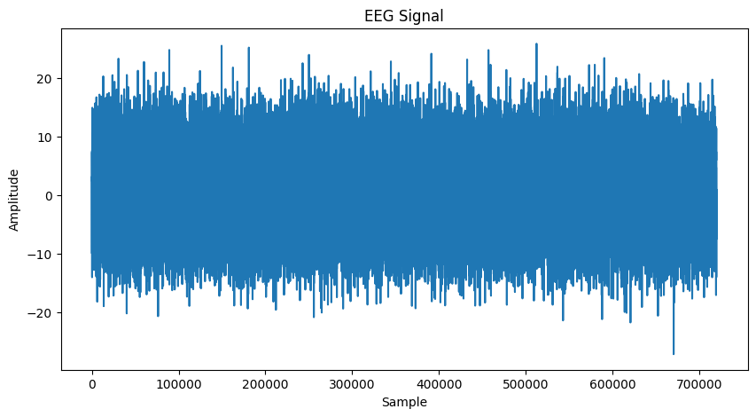

```
The sampling frequency is 1000 Hz
The length of the EEG data is 720000 samples
The duration of the EEG data is 720.0 seconds
```

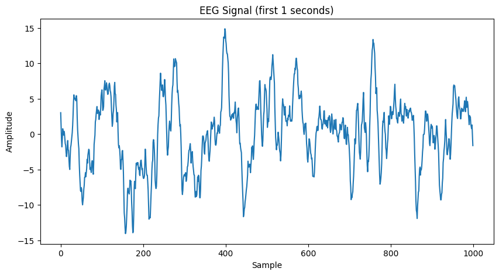

```python
from scipy import io
EEG_data = io.loadmat('EEG_exp.mat',squeeze_me = True)
print(EEG_data.keys())
EEG = EEG_data['EEG']
fs = EEG_data['fs']

# plot
plt.figure(figsize=(10,5))
plt.plot(EEG)
plt.title('EEG Signal')
plt.xlabel('Sample')
plt.ylabel('Amplitude')
plt.show()


# print relevant information
print('The sampling frequency is {} Hz'.format(fs))
print('The length of the EEG data is {} samples'.format(len(EEG)))
print('The duration of the EEG data is {} seconds'.format(len(EEG)/fs))

# plot the EEG data for the first 1 second1
plt.figure(figsize=(10,5))
plt.plot(EEG[:int(1*fs)])
plt.title('EEG Signal (first 1 seconds)')
plt.xlabel('Sample')
plt.ylabel('Amplitude')
plt.show()
```

### 3.2 Analog to Discrete time conversion

People used to analyze signals using analog circuits. This is hard and requires extensive firsthand knowledge about circuitry. Once you want to analyze the signal on a "digital" computer, you must "digitize" the signal. To digitize an analog signal, you must discretely sample, both in value (voltage, brightness, etc.) and in time. It is like drawing a grid over your continuous signals and interpolating its values only at where the grid crosses. The signal is already a digitally sampled (720,000 samples) time series represented by discrete points. This means that the signal is already stored as a digital signal since all computers are digital. But we assume this as a continuous signal and digitize it using a 4-bit ADC, means it will have 16 levels. A sample code for doing this is given below. Modify this and run it after loading the EEG files.

words, what is the finest voltage that can distinguish two samples

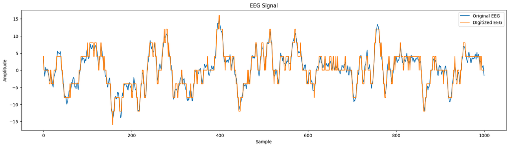

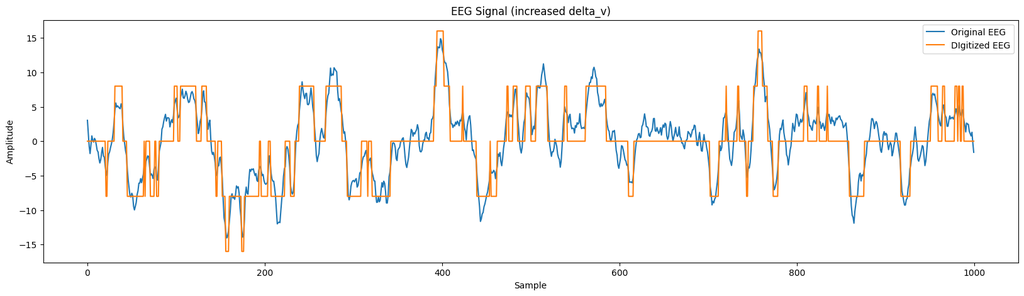

```python
min_v, max_v = -32,32
delta_v = 4 # voltage resolution: 4 bit adc can represent 2^4=16 values, range is 32-(-32)=64, so voltage resolution=64/16=4
# create the digitization vector with new possible values that your signal can take
ADC_levels = np.arange(min_v,max_v,delta_v)+delta_v/2
# digitize the EEG signal with our ADC with the function np.digitize
# note that we have to scale the redigitized signal to its original units
EEG_quant = np.digitize(EEG,bins=ADC_levels)*delta_v+min_v
# Plot the EEG signal and the digitized EEG signal on top of it, only want the first 1000 samples
plt.figure(figsize=(20,5))
plt.plot(EEG[:1000],label='Original EEG')
plt.plot(EEG_quant[:1000],label='DIgitized EEG')
plt.title('EEG Signal')
plt.xlabel('Sample')
plt.ylabel('Amplitude')
plt.legend()

plt.show()

# second pic as delta_v = 8
min_v, max_v = -32,32
delta_v = 8
ADC_levels = np.arange(min_v,max_v,delta_v)+delta_v/2
EEG_quant = np.digitize(EEG,bins=ADC_levels)*delta_v+min_v
plt.figure(figsize=(20,5))
plt.plot(EEG[:1000],label='Original EEG')
plt.plot(EEG_quant[:1000],label='DIgitized EEG')
plt.title('EEG Signal (increased delta_v)')
plt.xlabel('Sample')
plt.ylabel('Amplitude')
plt.legend()
plt.show()
```

Conclusion: increased delta_v will result in a less accurate representation of the signal.

- What are the number of possible voltage levels of the new digitized EEG signal? How is this related to "delta_v"?

Ans: The number of possible voltage levels of the new digitized EEG signal is 16. This is related to "delta_v" as "delta_v" is the voltage resolution and the finest voltage that can distinguish two samples. In this case, 64/16 = 4 mV is the voltage resolution and the finest voltage that can distinguish two samples.

- Find the minimum number of bits that can appropriately represent the EEG signal, justify.

```
The smallest voltage change in the original signal is 3.884892407768348e-11 uV
The average voltage change in the original signal is 7.356592239694874e-05 uV
The minimum number of bits needed to represent the EEG signal is -13.0
```

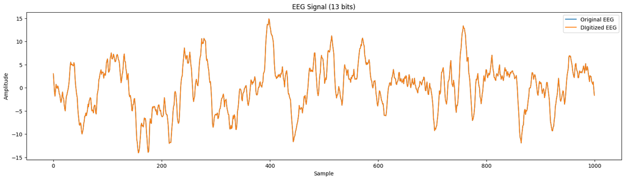

```python
"""
To find the minimum number of bits that can appropriately represent the EEG signal, it is really finding the smallest voltage change in the original signal,
and then figure out how many bits are needed to represent that voltage change.
"""
# find the smallest voltage change and the average voltage change in the original signal
min_voltage_change = np.min(np.diff(np.sort(EEG)))
print('The smallest voltage change in the original signal is {} uV'.format(min_voltage_change))

avg_voltage_change = np.mean(np.diff(np.sort(EEG)))
print('The average voltage change in the original signal is {} uV'.format(avg_voltage_change))

# find the minimum number of bits needed to represent the EEG signal
min_bits = np.ceil(np.log2(avg_voltage_change))
print('The minimum number of bits needed to represent the EEG signal is {}'.format(min_bits))

# trying out 13 bits
min_v, max_v = -32,32
delta_v = 64/2**13
ADC_levels = np.arange(min_v,max_v,delta_v)+delta_v/2
EEG_quant = np.digitize(EEG,bins=ADC_levels)*delta_v+min_v
plt.figure(figsize=(20,5))
plt.plot(EEG[:1000],label='Original EEG')
plt.plot(EEG_quant[:1000],label='DIgitized EEG')
plt.title('EEG Signal (13 bits)')
plt.xlabel('Sample')
plt.ylabel('Amplitude')
plt.legend()
plt.show()
```

### 3.3 Downsampling in time

The x-axis in the section 3.1 plot of EEG signal denotes the “sample number”, which corresponds to the position of each value in the EEG data array. In real life, the x-axis usually represents the time vector which marks the clock time at which the data is recorded. Sometimes the EEG datasets include a time vector, which is not the case here. So, in this exercise, we create the corresponding time vector.

A sample code for creating the time vector for the given EEG signal is given below. What is sampling period? Identify sampling rate from the Q3.1, that is from the EEG data. Use this to find the sampling period “dt”.

- What is the total time duration of the given EEG signal?
- What is the total number of samples of the EEG signal?

Use the sampling rate information and total number of samples to calculate the total duration of the signal. Let this value be “T_exp” in the code signifying the duration of the experiment.

Create a time vector corresponding to the EEG data with evenly spaced samples with an interval “dt”. Let this vector be “t_EEG” in the code. Hint: check the function `np.arange()`

Plot the EEG signal as a line chart with x-axis as the time (using “t_EEG”). Assume the EEG signal start at 0. Remember to label the plot with appropriate units.

To simulate down-sampling, plot every 10th value of the EEG signal. This applies to both the time vector and the EEG data. This can be done by indexing the array properly. Read on how to index an array in python. The provided sample code has the solution on how the array can be indexed at every 10th sample. Try indexing for different values and see how down sampling changes the EEG signal. Repeat the exercise with different down-sampling rate.

In 3.1:

- The sampling frequency is 1000 Hz
- The length of the EEG data is 720000 samples
- The duration of the EEG data is 720.0 seconds

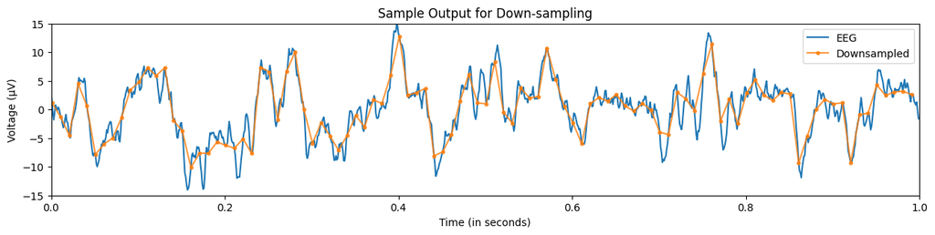

```python
# Given values
sampling_freq = 1000  # Sampling frequency in Hz
total_samples = 720000

# Calculating the sampling period (dt) and the total duration of the EEG signal (T_exp)
dt = 1 / sampling_freq
T_exp = total_samples / sampling_freq

# Creating the time vector (t_EEG)
t_EEG = np.arange(0, T_exp, dt)

# Downsampling rate
d_rate = 10

# Plotting the original EEG signal
plt.figure(figsize=(15, 3))
plt.plot(t_EEG[:1000], EEG[:1000], label='EEG')

# Plotting the downsampled EEG signal
plt.plot(t_EEG[1:1000:d_rate], EEG[1:1000:d_rate], '.-', label='Downsampled', alpha=0.8)

# Setting the x and y axis limits
plt.xlim([0, 1])
plt.ylim([-15, 15])

# Adding labels and title
plt.xlabel('Time (in seconds)')
plt.ylabel('Voltage (µV)')
plt.title('Sample Output for Down-sampling')

# Displaying the legend
plt.legend()

# Showing the plot
plt.show()
```

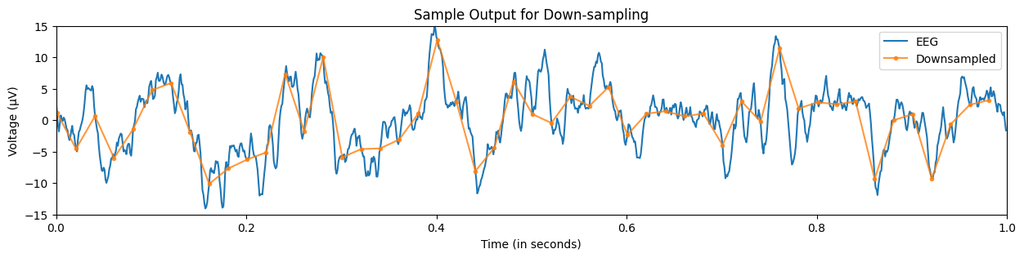

```python
# try out smaller downsampling rate
d_rate = 20
plt.figure(figsize=(15, 3))
plt.plot(t_EEG[:1000], EEG[:1000], label='EEG')
plt.plot(t_EEG[1:1000:d_rate], EEG[1:1000:d_rate], '.-', label='Downsampled', alpha=0.8)
plt.xlim([0, 1])
plt.ylim([-15, 15])
plt.xlabel('Time (in seconds)')
plt.ylabel('Voltage (µV)')
plt.title('Sample Output for Down-sampling')
plt.legend()
plt.show()
```

## 4. Polar plot of signals (Optional)

Write a python program to generate and plot the following discrete time signal $$y[n] = A^n e^{j(\omega n + \phi)}$$ where $A$ is a real number, digital frequency $\omega$ (in radian/sample), phase shift $\phi$ (radian), for a given range $n = 0...N$, and $n, N \in \mathbb{Z}$. Sample code is given below. You may edit the code as required. Experiment with different values of $\phi$, $\omega$ and $A$. Visualize the complex discrete sequence $y[n]$ in 3 ways, e.g., $A=0.95$, $\omega = \frac{2\pi}{36}$.

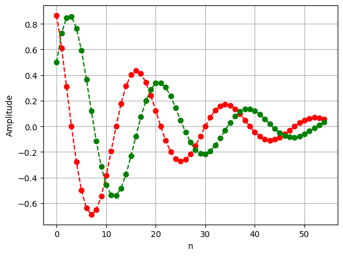

```python
A= 0.95
w1= 2*np.pi/18
Phi = np.pi/6
numSamples = 55
n = np.arange(0 , numSamples, 1)
y1 = np.multiply(np.power(A,n),np.exp(1j*(w1*n+Phi)))
# plot the signals in 2D, Q4.1
plt.figure(1)
plt.plot(n, y1[0:numSamples].real,'r--o')
plt.plot(n, y1[0:numSamples].imag,'g--o')
plt.xlabel('n')
plt.ylabel('Amplitude')
plt.grid()
```

### 4.1 Polar plots of the sequence

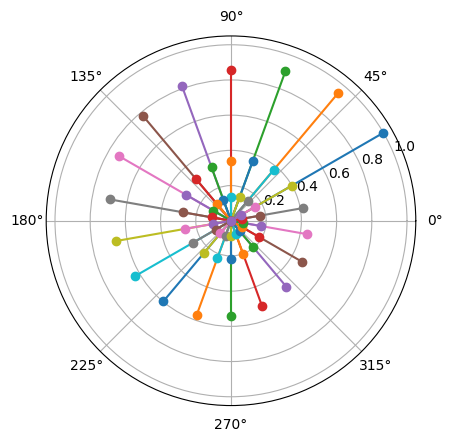

```python
# plot in polar
plt.figure(2)
for x in y1:
        plt.polar([0,np.angle(x)],[0,np.abs(x)],marker='o')
```

### 4.2 3-D plot showing trajectory with respect to sample index

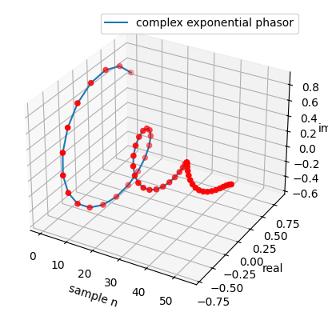

```python
# plotting 3D complex plane
plt.rcParams['legend.fontsize'] = 10
fig = plt.figure()
ax = fig.add_subplot(projection='3d')
reVal = y1[0:numSamples].real
imgVal = y1[0:numSamples].imag
ax.plot(n,reVal, imgVal,  label='complex exponential phasor')
ax.scatter(n,reVal,imgVal, c='r', marker='o')
ax.set_xlabel('sample n')
ax.set_ylabel('real')
ax.set_zlabel('imag')
ax.legend()
plt.show()
```